# 3-2. 하이퍼파라미터 최적화_베이지안(LightGBM)

## 하이퍼파라미터 최적화: 베이지안 최적화(Bayesian Optimization)

아래와 같은 과정으로 베이지안 최적화 하이퍼파라미터 최적화를 진행한다.

과거 데이터가 학습된 모델을 통해 현 시점의 대출 사기 여부를 예측하는 현업 방식과 유사하도록 아래와 같은 데이터셋을 구성한다.

- 최적의 하이퍼파라미터 탐색: 학습(2017년 이전 데이터) / 평가(2017년 데이터)
- 최적화된 모델 성능 평가: 학습(2018년 이전 데이터) / 평가(2018년 데이터)

### 함수호출

```python
import warnings
warnings.filterwarnings('ignore')

import os, sys, gc, warnings, random, datetime

import pandas as pd
import numpy as np

from sklearn.preprocessing import LabelEncoder
from sklearn.metrics import roc_auc_score, f1_score, precision_recall_curve, accuracy_score
from sklearn.model_selection import KFold, StratifiedKFold

import lightgbm as lgb

from matplotlib import pyplot as plt
import seaborn as sns

from IPython.display import display
from bayes_opt import BayesianOptimization



from sklearn import metrics
from sklearn.model_selection import train_test_split
import joblib

pd.set_option('display.max_columns', 200)
```

### SEED 고정

```python
def seed_everything(seed=0):
    random.seed(seed)
    os.environ['PYTHONHASHSEED'] = str(seed)
    np.random.seed(seed)

SEED = 42
seed_everything(SEED)
```

### 데이터 불러오기

```python
### Load Data
df = pd.read_pickle('../Data/feature_selected.pkl')
```

### 모델 성능 평가용 데이터

최적화된 하이퍼파라미터를 적용해 최종 모델 성능 지표를 산출할 데이터를 분리한다.

#### 대출 신청 연도 추출

```python
df['issue_d'] = pd.to_datetime(df['issue_d'])
df['issue_year'] = df['issue_d'].dt.year
```

#### 학습/평가 데이터 분리

```python
train = df[df['issue_year'] != 2018]
test = df[df['issue_year'] == 2018]
```

```python
answer = test[['id','loan_status']]
```

#### 학습 데이터 내 독립변수(X) / 종속변수(y) 분리:

```python
# Load Data with selected features
X = train.copy()
# Labels
y = train['loan_status']

# Remove Labels from Dataframe
X.drop(['loan_status'], axis = 1, inplace = True)
# Final Data Shapes
print(X.shape)
print(y.shape)
```

```
(1314290, 104)
(1314290,)
```

### 하이퍼파라미터 탐색용 데이터

베이지안 최적화 (Bayesian Optimization)기법으로 하이퍼파라미터 최적화를 진행할 데이터를 분리한다.

#### 학습/검증 데이터 분리:

```python
ttrain = train[train['issue_year'] != 2017]
ttest = train[train['issue_year'] == 2017]
```

#### 데이터 내 독립변수(X_train, X_test) / 종속변수(y_train, y_test) 분리:

```python
X_train = ttrain.copy()
y_train = ttrain['loan_status']
X_train.drop(['loan_status'], axis = 1, inplace = True)

X_test = ttest.copy()
y_test = ttest['loan_status']
X_test.drop(['loan_status'], axis = 1, inplace = True)
```

#### 독립변수 지정(id, 종속변수, 날짜변수 등 제외):

```python
remove_features = ['earliest_cr_line', 'issue_d', 'last_credit_pull_d', 'last_pymnt_d', 'next_pymnt_d',
                  'initial_list_status','out_prncp','out_prncp_inv','total_pymnt','total_pymnt_inv','total_rec_prncp','total_rec_int','total_rec_late_fee',
                   'recoveries','collection_recovery_fee','last_pymnt_amnt','last_fico_range_high','last_fico_range_low' , 'id', 'loan_status' , 'issue_year', 'addr_state','sub_grade']
features  = [col for col in list(train) if col not in remove_features]
```

#### Feature Selection 과정에서 최정 선정된 feature만 모델에 적용

```python
features = ["int_rate","dti","annual_inc","mo_sin_old_rev_tl_op","acc_open_past_24mths","loan_amnt","emp_length",
                    "revol_bal", "term", "funded_amnt_inv", "installment", "purpose",
                    "total_rev_hi_lim","fico_range_low","debt_settlement_flag", "mort_acc","total_bc_limit","home_ownership",
                    "avg_cur_bal","all_util","mths_since_recent_bc","total_acc","open_acc_6m","bc_util","num_actv_rev_tl",
                    "funded_amnt","hardship_flag","num_rev_tl_bal_gt_0","mths_since_recent_inq","inq_last_6mths", "num_il_tl",
                    "mo_sin_old_il_acct","num_rev_accts","num_tl_120dpd_2m","total_il_high_credit_limit","application_type",
                    "revol_util","tot_hi_cred_lim","delinq_2yrs","mo_sin_rcnt_tl","num_actv_bc_tl","mths_since_last_record",
                    "percent_bc_gt_75", "bc_open_to_buy","max_bal_bc","grade","open_rv_24m","mo_sin_rcnt_rev_tl_op",
                    "pct_tl_nvr_dlq","verification_status","tot_cur_bal","total_bal_ex_mort","mths_since_last_major_derog",
                    "inq_fi","mths_since_rcnt_il","inq_last_12m","mths_since_last_delinq","num_bc_tl"]
```

```python
X_train = X_train[features]
X_test = X_test[features]
```

### 베이지안 최적화 (Bayesian Optimization)

- 하이퍼파라미터 별 탐색 범위 지정
- 베이지안 최적화 후 최적값 저장

#### 하이퍼파라미터 별 탐색 범위 지정:

- num_leaves : 예측 트리에서 데이터가 분기되는 가지의 수
- subsample : 데이터를 샘플링하는 비율
- colsample_bytree : 개별 트리를 학습할 때 무작위로 선택하는 피처의 비율
- max_bin : 피처 값의 최대 bin의 수

```python
bounds = {
    'num_leaves': (50, 70),
    'subsample' : (0.5, 1),
    'colsample_bytree' : (0.5, 1),
    'max_bin' : (49, 69) }
```

#### 베이지안 최적화 함수 지정 및 실행

```python
def train_model( num_leaves, colsample_bytree, subsample , max_bin):

    params = {
                    'objective':'binary',
                    'boosting_type':'gbdt',
                    'metric':'auc',
                    'n_jobs':-1,
                    'learning_rate':0.05,
                    'num_leaves': int(num_leaves),
                    'max_depth':-1,
                    'tree_learner':'serial',
                    'colsample_bytree' : colsample_bytree,
                    'subsample_freq':1,
                    'subsample' : subsample,
                    'n_estimators':10000,
                    'max_bin':int(max_bin),
                    'verbose':-1,
                    'seed': SEED,
                    'early_stopping_rounds':50,

          }

    trn_data = lgb.Dataset(X_train, y_train)
    val_data = lgb.Dataset(X_test, y_test)
    model = lgb.train(params, trn_data, 5000, valid_sets = [trn_data, val_data], verbose_eval=0, early_stopping_rounds=50)
    # Returning negative rmse because optimizer tries to maximize a function
    return model.best_score['valid_1']['auc']
```

```python
optimizer = BayesianOptimization(f=train_model, pbounds=bounds, random_state=2021)


optimizer.maximize(init_points=10, n_iter=10)
```

[output not shown]

#### 최적의 하이퍼파라미터 저장

```python
optimizer.max['params']
```

```python
lgb_params = {
                    'objective':'binary',
                    'boosting_type':'gbdt',
                    'metric':'auc',
                    'n_jobs':-1,
                    'learning_rate':0.05,
                    'num_leaves': int(optimizer.max['params']['num_leaves']),
                    'max_depth':-1,
                    'tree_learner':'serial',
                    'colsample_bytree' : optimizer.max['params']['colsample_bytree'],
                    'subsample_freq':1,
                    'subsample' : optimizer.max['params']['subsample'],
                    'n_estimators':10000,
                    'max_bin':int(optimizer.max['params']['max_bin']),
                    'verbose':-1,
                    'seed': SEED,
                    'early_stopping_rounds':100,

}
```

#### y_train, y_test 지정

```python
y_train = train.pop('loan_status')
y_test = test.pop('loan_status')
train.reset_index(drop=True, inplace=True)
test.reset_index(drop=True, inplace=True)
y_train.reset_index(drop=True, inplace=True)
y_test.reset_index(drop=True, inplace=True)
```

#### LightGBM 모델

- K-Fold 교차검증을 통해 과적합 이슈를 방지
- 베이지안 최적화를 통해 지정된 최적의 하이퍼 파라미터 값을 사용

```python
def make_lgb_prediction(train, y, test, features, categorical_features='auto', model_params=None, folds=5):

    skf = KFold(n_splits=folds, random_state=SEED, shuffle=True)
    folds = 5
    x_train = train[features]
    x_test = test[features]

    y_preds = np.zeros(x_test.shape[0])
    y_oof = np.zeros(x_train.shape[0])
    score = 0
    split_groups = train['issue_year']
    feature_importance = pd.DataFrame()


    for fold, (tr_idx, val_idx) in enumerate(skf.split(x_train, y)):
        print(f'Fold: {fold+1}')

        x_tr, x_val = x_train.loc[tr_idx, features], x_train.loc[val_idx, features]
        y_tr, y_val = y[tr_idx], y[val_idx]

        print(x_tr.shape, x_val.shape)

        dtrain = lgb.Dataset(x_tr, label=y_tr)
        dvalid = lgb.Dataset(x_val, label=y_val)

        clf = lgb.train(
            model_params,
            dtrain,
            valid_sets=[dtrain, dvalid],
            categorical_feature=categorical_features,
            verbose_eval=200,
            early_stopping_rounds=100,
#             feval=lgb_f1_score
        )

        fold_importance_df = pd.DataFrame()
        fold_importance_df["Feature"] = features
        fold_importance_df["importance"] = clf.feature_importance()
        fold_importance_df["fold"] = fold + 1
        feature_importance = pd.concat([feature_importance, fold_importance_df], axis=0)

        y_pred_val = clf.predict(x_val)

        y_oof[val_idx] = y_pred_val
        print(f"Fold {fold + 1} | AUC Score: {roc_auc_score(y_val, y_pred_val)}")

        score += roc_auc_score(y_val, y_pred_val) / folds
        y_preds += clf.predict(x_test) / folds
        joblib.dump(clf, f'/home/work/toy-project/model/lgbm_BayesOpt_Fold_{fold+1}.pkl')

        del x_tr, x_val, y_tr, y_val
        gc.collect()

    print(f"\nMean AUC score = {score}")
    print(f"OOF AUC score = {roc_auc_score(y, y_oof)}")

    return y_oof, y_preds, feature_importance
```

#### 모델 성능 확인:

```python
y_oof_lgb, y_preds_lgb, fi_lgb = make_lgb_prediction(train, y_train, test, features, model_params=lgb_params)
```

```
Fold: 1
(1051432, 58) (262858, 58)
Training until validation scores don't improve for 100 rounds
[200]	training's auc: 0.77827	valid_1's auc: 0.767002
[400]	training's auc: 0.789726	valid_1's auc: 0.768738
[600]	training's auc: 0.799194	valid_1's auc: 0.769041
[800]	training's auc: 0.808008	valid_1's auc: 0.769218
[1000]	training's auc: 0.81612	valid_1's auc: 0.769338
Early stopping, best iteration is:
[1032]	training's auc: 0.817328	valid_1's auc: 0.769382
Fold 1 | AUC Score: 0.7693819280122165
Fold: 2
(1051432, 58) (262858, 58)
Training until validation scores don't improve for 100 rounds
[200]	training's auc: 0.777693	valid_1's auc: 0.769971
[400]	training's auc: 0.789235	valid_1's auc: 0.771497
[600]	training's auc: 0.798724	valid_1's auc: 0.77172
[800]	training's auc: 0.807443	valid_1's auc: 0.771783
Early stopping, best iteration is:
[740]	training's auc: 0.804837	valid_1's auc: 0.771815
Fold 2 | AUC Score: 0.7718149549704655
Fold: 3
(1051432, 58) (262858, 58)
Training until validation scores don't improve for 100 rounds
[200]	training's auc: 0.778009	valid_1's auc: 0.767827
[400]	training's auc: 0.789486	valid_1's auc: 0.769377
[600]	training's auc: 0.799018	valid_1's auc: 0.769835
[800]	training's auc: 0.80765	valid_1's auc: 0.769989
Early stopping, best iteration is:
[841]	training's auc: 0.809345	valid_1's auc: 0.770024
Fold 3 | AUC Score: 0.7700243139787586
Fold: 4
(1051432, 58) (262858, 58)
Training until validation scores don't improve for 100 rounds
[200]	training's auc: 0.778262	valid_1's auc: 0.76702
[400]	training's auc: 0.789641	valid_1's auc: 0.768751
[600]	training's auc: 0.798965	valid_1's auc: 0.769146
Early stopping, best iteration is:
[688]	training's auc: 0.802838	valid_1's auc: 0.769234
Fold 4 | AUC Score: 0.7692338273351117
Fold: 5
(1051432, 58) (262858, 58)
Training until validation scores don't improve for 100 rounds
[200]	training's auc: 0.778096	valid_1's auc: 0.767573
[400]	training's auc: 0.789663	valid_1's auc: 0.769323
[600]	training's auc: 0.798989	valid_1's auc: 0.769652
[800]	training's auc: 0.807531	valid_1's auc: 0.769775
Early stopping, best iteration is:
[883]	training's auc: 0.8109	valid_1's auc: 0.769864
Fold 5 | AUC Score: 0.7698642313401962

Mean AUC score = 0.7700638511273497
OOF AUC score = 0.7700606228944421
```

#### 학습/예측 결과 분석을 위한 데이터 저장

```python
train['y_oof_prediction'] = y_oof_lgb
train['loan_status'] = y
train_record = train[['id','y_oof_prediction','loan_status']]

train_record.to_pickle('../Data/model/train_record.pkl')
fi_lgb.to_pickle('../Data/model/fi_lgb.pkl')
```

#### Test 데이터에 대한 정확도 (AUC)

```python
print(f"TEST AUC score = {roc_auc_score(answer['loan_status'], y_preds_lgb)}")
```

```
TEST AUC score = 0.7389545245399067
```

### 변수 중요도 (Feature Importance)

- 모델의 중요한 변수를 볼 수 있는 그래프 생성

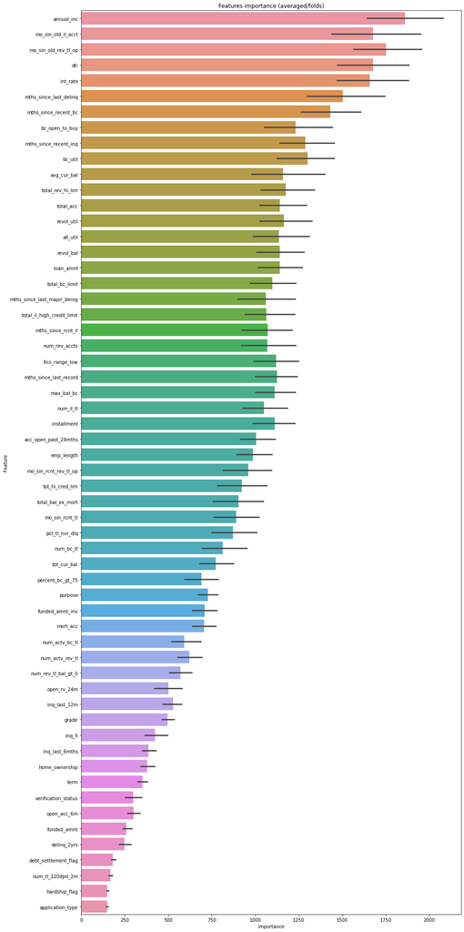

```python
cols = (fi_lgb[["Feature", "importance"]]
        .groupby("Feature")
        .mean()
        .sort_values(by="importance", ascending=False)[:150].index)
best_features = fi_lgb.loc[fi_lgb.Feature.isin(cols)]

plt.figure(figsize=(14,28))
sns.barplot(x="importance", y="Feature", data=best_features.sort_values(by="importance",ascending=False))
plt.title('Features importance (averaged/folds)')
plt.tight_layout()
plt.savefig('FI.png')
```